# HC_DENDROGRAM SOLUTIONS

Alberto Montero Solera

martes 08, octubre 2024. 23:01:42

# 1 Initial description

Given the following distance matrix, draw the dendogram for HIERARCHICAL AGGLOMERATIVE CLUSTERING in the following cases:

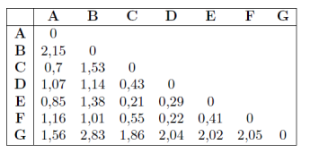

**Figura 1**:Initial Distance Matrix

# 2 Cases

To verify the results obtained manually I’m going to use the next libraries:

- **dendextend**
- **factoextra**

```r
if(!require("dendextend", quietly = TRUE)){
  install.packages("dendextend", dependencies = TRUE)
  library(dendextend)
}

if(!require("factoextra", quietly = TRUE)){
  install.packages("factoextra", dependencies = TRUE)
  library("factoextra")
}

if(!require("knitr", quietly = TRUE)){
  install.packages("knitr", dependencies = TRUE)
  library("knitr")
}
```

## 2.1 Single Link Agglomerative Clustering

In Single Link, in each iteration, the pair of clusters with the minimum distance is selected.

### 2.1.1 Iteration 1

The minimum distance is 0.21 between *C* and *E* so we cluster them.

[output not shown]

### 2.1.2 Iteration 2

[output not shown]

### 2.1.3 Iteration 3

|  | A | B | CEFD |
| --- | --- | --- | --- |
| A | 0 | 2.15 | 0.7 |
| B | 2.15 | 0 | 1.01 |
| CEFD | 0.7 | 1.01 | 0 |
| G | 1.56 | 2.83 | 1.86 |

### 2.1.4 Iteration 4

The minimum distance is 0.7 and is between *A* and *CEFD*.

[output not shown]

### 2.1.5 Iteration 5

The minimum distance is 1.01 between *B* and *ACEFD*.

[output not shown]

### 2.1.6 Final result

The final result would be obtained by grouping *G* with *BACEFD*.

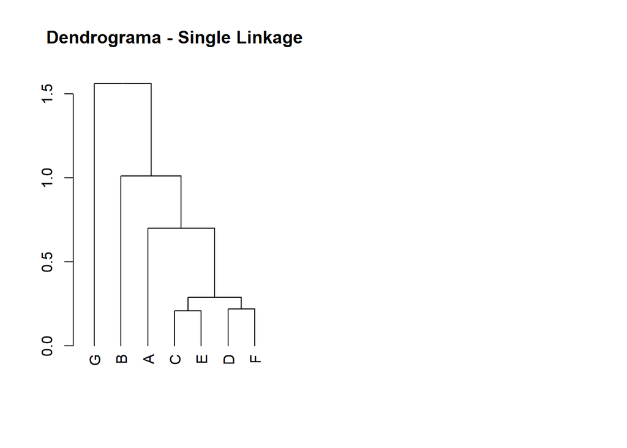

```r
distancias <- matrix(c(
  0, 2.15, 0.7, 1.07, 0.85, 1.16, 1.56,
  2.15, 0, 1.53, 1.14, 1.38, 1.01, 2.83,
  0.7, 1.53, 0, 0.43, 0.21, 0.55, 1.86,
  1.07, 1.14, 0.43, 0, 0.29, 0.22, 2.04,
  0.85, 1.38, 0.21, 0.29, 0, 0.41, 2.02,
  1.16, 1.01, 0.55, 0.22, 0.41, 0, 2.05,
  1.56, 2.83, 1.86, 2.04, 2.02, 2.05, 0
), nrow=7, byrow=TRUE)

rownames(distancias) <- colnames(distancias) <- c("A", "B", "C", "D", "E", "F", "G")

hc_single <- hclust(as.dist(distancias), method = "single")
dend_single <- as.dendrogram(hc_single)

par(mfrow = c(1, 2))

plot(dend_single, main = "Dendrograma - Single Linkage")
```

## 2.2 Complete Link Agglomerative Clustering

### 2.2.1 Iteration 1

The minimum distance is 0.21 between *c* and *E*.

|  | A | B | CE | D | F |
| --- | --- | --- | --- | --- | --- |
| A | 0 | 2.15 | 0.85 | 1.07 | 1.16 |
| B | 2.15 | 0 | 1.53 | 1.14 | 1.01 |
| CE | 0.85 | 1.53 | 0 | 0.43 | 0.55 |
| D | 1.07 | 1.14 | 0.43 | 0 | 0.22 |
| F | 1.16 | 1.01 | 0.55 | 0.22 | 0 |
| G | 1.56 | 2.83 | 2.02 | 2.04 | 2.05 |

### 2.2.2 Iteration 2

The new minimum distance is 0.22 between *D* and *F*. Then we group *D* and *F* in the cluster *DF*.

[output not shown]

### 2.2.3 Iteration 3

The minimum distance is 0.55 between *CE* and *DF* so we group them.

|  | A | B | CEDF |
| --- | --- | --- | --- |
| A | 0 | 2.15 | 1.16 |
| B | 2.15 | 0 | 1.53 |
| CEDF | 1.16 | 1.53 | 0 |
| G | 1.56 | 2.83 | 2.04 |

### 2.2.4 Iteration 4

The minimum distance is 1.16 and is between *A* and *CEDF*.

[output not shown]

### 2.2.5 Iteration 5

|  | ACEFDG |
| --- | --- |
| ACEFDG | 0 |
| B | 2.83 |

### 2.2.6 Final result

The final result would be obtained by grouping *B* with *ACEFDG*.

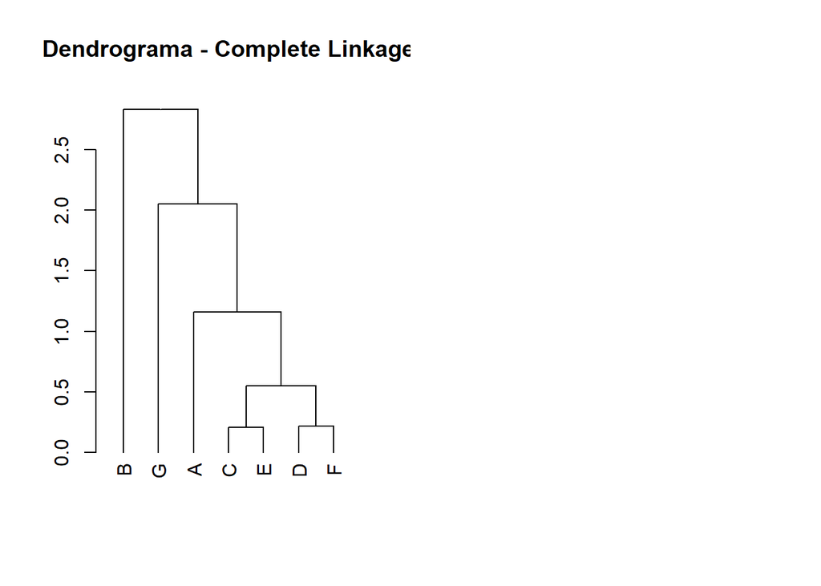

```r
distancias <- matrix(c(
  0, 2.15, 0.7, 1.07, 0.85, 1.16, 1.56,
  2.15, 0, 1.53, 1.14, 1.38, 1.01, 2.83,
  0.7, 1.53, 0, 0.43, 0.21, 0.55, 1.86,
  1.07, 1.14, 0.43, 0, 0.29, 0.22, 2.04,
  0.85, 1.38, 0.21, 0.29, 0, 0.41, 2.02,
  1.16, 1.01, 0.55, 0.22, 0.41, 0, 2.05,
  1.56, 2.83, 1.86, 2.04, 2.02, 2.05, 0
), nrow=7, byrow=TRUE)

rownames(distancias) <- colnames(distancias) <- c("A", "B", "C", "D", "E", "F", "G")

hc_complete <- hclust(as.dist(distancias), method = "complete")

dend_complete <- as.dendrogram(hc_complete)

par(mfrow = c(1, 2))

plot(dend_complete, main = "Dendrograma - Complete Linkage")
```

## 2.3 Group Average Agglomerative Clustering

In Group Average, the distance between clusters is the average of all distances between the points.

### 2.3.1 Iteration 1

The minimum distance is 0.21 between *C* and *E*.

|  | A | B | CE | D | F |
| --- | --- | --- | --- | --- | --- |
| A | 0 | 2.15 | 0.775 | 1.07 | 1.16 |
| B | 2.15 | 0 | 1.455 | 1.14 | 1.01 |
| CE | 0.775 | 1.455 | 0 | 0.36 | 0.48 |
| D | 1.07 | 1.14 | 0.36 | 0 | 0.22 |
| F | 1.16 | 1.01 | 0.48 | 0.22 | 0 |
| G | 1.56 | 2.83 | 1.955 | 2.04 | 2.05 |

### 2.3.2 Iteration 2

The new minimum distance is 0.22 between *D* and *F*. Then we group *D* and *F* in the cluster *DF*.

|  | A | B | CE | DF |
| --- | --- | --- | --- | --- |
| A | 0 | 2.15 | 0.775 | 1.115 |
| B | 2.15 | 0 | 1.455 | 1.075 |
| CE | 0.775 | 1.455 | 0 | 0.42 |
| DF | 1.115 | 1.075 | 0.42 | 0 |
| G | 1.56 | 2.83 | 1.955 | 2.045 |

### 2.3.3 Iteration 3

The minimum distance is 0.42 between *CE* and *DF* so we group them.

|  | A | B | CEDF |
| --- | --- | --- | --- |
| A | 0 | 2.15 | 0.945 |
| B | 2.15 | 0 | 1.265 |
| CEDF | 0.945 | 1.265 | 0 |
| G | 1.56 | 2.83 | 2 |

### 2.3.4 Iteration 4

The minimum distance is 0.945 and is between *A* and *CEDF*.

[output not shown]

### 2.3.5 Iteration 5

[output not shown]

### 2.3.6 Final result

The final result would be obtained by grouping *G* with *ABCEFD*.

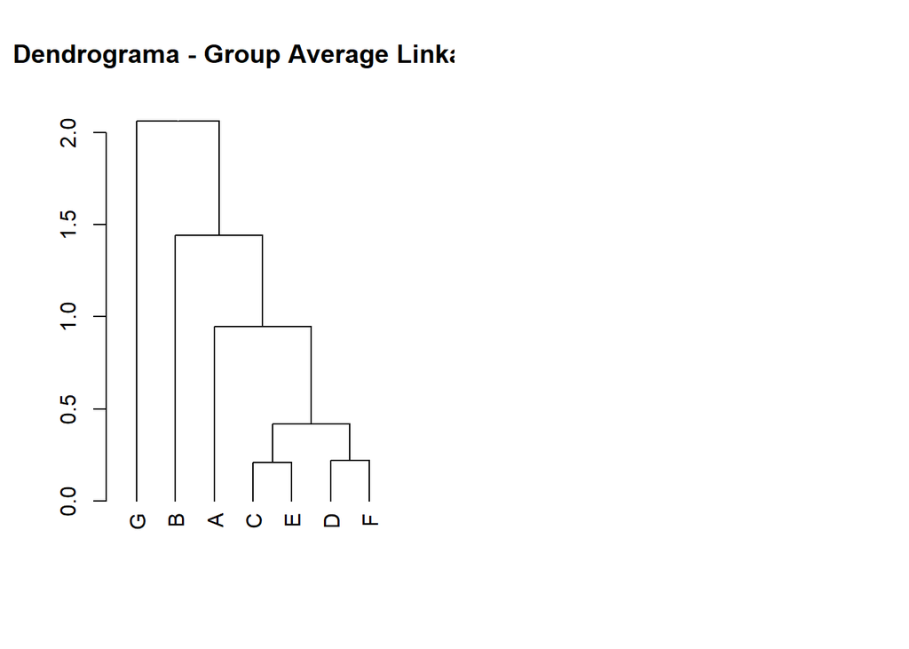

```r
distancias <- matrix(c(
  0, 2.15, 0.7, 1.07, 0.85, 1.16, 1.56,
  2.15, 0, 1.53, 1.14, 1.38, 1.01, 2.83,
  0.7, 1.53, 0, 0.43, 0.21, 0.55, 1.86,
  1.07, 1.14, 0.43, 0, 0.29, 0.22, 2.04,
  0.85, 1.38, 0.21, 0.29, 0, 0.41, 2.02,
  1.16, 1.01, 0.55, 0.22, 0.41, 0, 2.05,
  1.56, 2.83, 1.86, 2.04, 2.02, 2.05, 0
), nrow=7, byrow=TRUE)

rownames(distancias) <- colnames(distancias) <- c("A", "B", "C", "D", "E", "F", "G")

hc_average <- hclust(as.dist(distancias), method = "average")

dend_average <- as.dendrogram(hc_average)

par(mfrow = c(1, 2))

plot(dend_average, main = "Dendrograma - Group Average Linkage")
```